# INDIA AIR QUALITY DATA ANALYSIS, VISUALISATION AND PREDICTION

# DROP UNNECESSARY COLUMN

```python
data.drop(['stn_code','agency','sampling_date','location_monitoring_station'],axis=1,inplace=True)
```

```python
data.head(10)
```

|  | state | location | type | so2 | no2 | rspm | spm | pm2_5 | date |
| --- | --- | --- | --- | --- | --- | --- | --- | --- | --- |
| 0 | Andhra Pradesh | Hyderabad | Residential, Rural and other Areas | 4.8 | 17.4 | NaN | NaN | NaN | 2/1/1990 |
| 1 | Andhra Pradesh | Hyderabad | Industrial Area | 3.1 | 7.0 | NaN | NaN | NaN | 2/1/1990 |
| 2 | Andhra Pradesh | Hyderabad | Residential, Rural and other Areas | 6.2 | 28.5 | NaN | NaN | NaN | 2/1/1990 |
| 3 | Andhra Pradesh | Hyderabad | Residential, Rural and other Areas | 6.3 | 14.7 | NaN | NaN | NaN | 3/1/1990 |
| 4 | Andhra Pradesh | Hyderabad | Industrial Area | 4.7 | 7.5 | NaN | NaN | NaN | 3/1/1990 |
| 5 | Andhra Pradesh | Hyderabad | Residential, Rural and other Areas | 6.4 | 25.7 | NaN | NaN | NaN | 3/1/1990 |
| 6 | Andhra Pradesh | Hyderabad | Residential, Rural and other Areas | 5.4 | 17.1 | NaN | NaN | NaN | 4/1/1990 |
| 7 | Andhra Pradesh | Hyderabad | Industrial Area | 4.7 | 8.7 | NaN | NaN | NaN | 4/1/1990 |
| 8 | Andhra Pradesh | Hyderabad | Residential, Rural and other Areas | 4.2 | 23.0 | NaN | NaN | NaN | 4/1/1990 |
| 9 | Andhra Pradesh | Hyderabad | Industrial Area | 4.0 | 8.9 | NaN | NaN | NaN | 5/1/1990 |

# CALCULATE TOTAL MISSING VALUES AND THEIR PERCENTAGE

```python
total = data.isnull().sum().sort_values(ascending=False)
```

```python
total.head()
```

```
pm2_5    426428
spm      237387
rspm      40222
so2       34646
no2       16233
dtype: int64
```

```python
percent = (data.isnull().sum()/data.isnull().count()*100).sort_values(ascending=False)  #count(returns Non-NAN value)
```

```python
missing_data = pd.concat([total, percent], axis=1, keys=['Total', 'Percent'])
```

```python
missing_data.head()
```

|  | Total | Percent |
| --- | --- | --- |
| pm2_5 | 426428 | 97.862497 |
| spm | 237387 | 54.478797 |
| rspm | 40222 | 9.230692 |
| so2 | 34646 | 7.951035 |
| no2 | 16233 | 3.725370 |

# PERCENT OF MISSING VALUE (BAR PLOT)

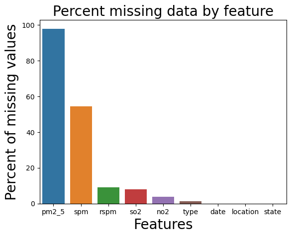

```python
sns.barplot(x=missing_data.index, y=missing_data['Percent'])
plt.xlabel('Features', fontsize=20)
plt.ylabel('Percent of missing values', fontsize=20)
plt.title('Percent missing data by feature', fontsize=20)
plt.show()
```

# MEAN DISTRIBUTION BY STATE

```python
data.groupby('state')[['spm','pm2_5','rspm','so2','no2']].mean()
```

| state | spm | pm2_5 | rspm | so2 | no2 |
| --- | --- | --- | --- | --- | --- |
| Andhra Pradesh | 200.260378 | NaN | 78.182824 | 7.284845 | 21.704451 |
| Arunachal Pradesh | NaN | NaN | 76.629213 | 3.179104 | 5.469697 |
| Assam | 153.355386 | NaN | 93.724912 | 6.723263 | 14.793691 |
| Bihar | 276.917416 | NaN | 123.705176 | 19.381476 | 36.575525 |
| Chandigarh | 206.056150 | NaN | 96.587079 | 2.676986 | 18.619404 |
| Chhattisgarh | 231.290969 | NaN | 126.472399 | 12.846609 | 24.815961 |
| Dadra & Nagar Haveli | 170.545024 | 30.511628 | 76.536530 | 8.939587 | 18.293959 |
| Daman & Diu | 145.681416 | 27.886364 | 73.749431 | 8.192958 | 16.168926 |
| Delhi | 399.402088 | 95.113208 | 196.639771 | 8.737273 | 53.489147 |
| Goa | 67.254193 | 18.855612 | 61.212766 | 6.827913 | 12.506337 |
| Gujarat | 191.567930 | 30.729696 | 98.244510 | 16.656343 | 24.065631 |
| Haryana | 268.264804 | NaN | 149.860537 | 14.064957 | 23.428311 |
| Himachal Pradesh | 208.575630 | NaN | 91.870202 | 2.667013 | 13.658688 |
| Jammu & Kashmir | 196.221053 | NaN | 117.449483 | 7.180521 | 12.213181 |
| Jharkhand | 277.940746 | NaN | 168.517763 | 23.485794 | 43.366341 |
| Karnataka | 168.001743 | NaN | 79.371801 | 10.223099 | 22.702837 |
| Kerala | 84.419791 | NaN | 50.636064 | 5.322350 | 14.421889 |
| Lakshadweep | NaN | NaN | NaN | NaN | NaN |
| Madhya Pradesh | 210.067545 | 65.064565 | 114.717967 | 11.587410 | 18.639596 |
| Maharashtra | 205.255823 | NaN | 101.479608 | 17.366863 | 32.115370 |
| Manipur | 158.657895 | NaN | 69.815789 | 3.900000 | 20.173684 |
| Meghalaya | 78.002445 | NaN | 68.988442 | 8.955908 | 10.659706 |
| Mizoram | 87.833333 | NaN | 42.716466 | 2.085009 | 6.682171 |
| Nagaland | 133.311449 | NaN | 83.357027 | 2.059736 | 8.947265 |
| Odisha | 167.609844 | 42.204089 | 83.619824 | 5.275874 | 16.899568 |
| Puducherry | 95.598188 | NaN | 43.418217 | 11.970639 | 15.279496 |
| Punjab | 244.918926 | NaN | 173.493711 | 10.628598 | 28.085846 |
| Rajasthan | 300.735397 | NaN | 142.016832 | 7.665725 | 30.441008 |
| Sikkim | 75.000000 | NaN | 32.000000 | 19.800000 | 26.800000 |
| Tamil Nadu | 126.729064 | 29.550441 | 66.585638 | 11.315134 | 21.601202 |
| Telangana | NaN | 43.968927 | 85.043008 | 5.418609 | 23.864005 |
| Tripura | NaN | NaN | NaN | NaN | NaN |
| Uttar Pradesh | 372.663688 | NaN | 176.952308 | 12.528500 | 27.610095 |
| Uttarakhand | 306.758923 | NaN | 148.978906 | 24.372957 | 26.938090 |
| Uttaranchal | 283.335714 | NaN | 121.694340 | 24.697736 | 27.163019 |
| West Bengal | 233.506524 | 64.890625 | 115.039909 | 12.608766 | 59.075731 |
| andaman-and-nicobar-islands | NaN | NaN | NaN | NaN | NaN |

# CHECKING DATA DISTRIBUTION

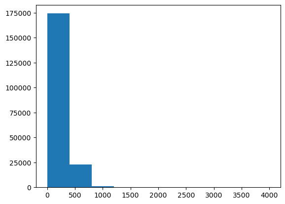

```python
plt.hist(data.spm,range=(0.0,4000)) #spm
plt.show()
```

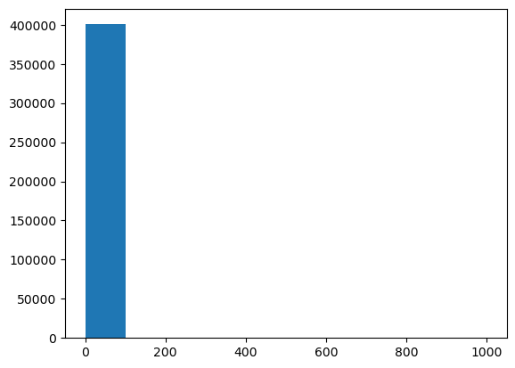

```python
plt.hist(data.so2,range=(0,1000)) #so2
plt.show()
```

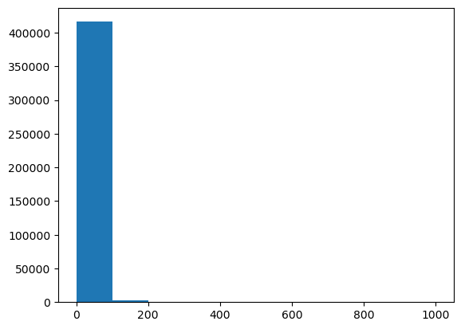

```python
plt.hist(data.no2,range=(0,1000)) #no2
plt.show()
```

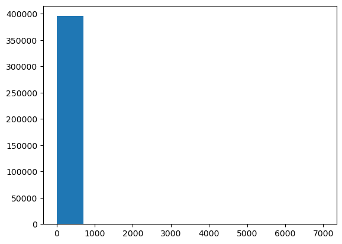

```python
plt.hist(data.rspm,range=(0,7000)) #rspm
plt.show()
```

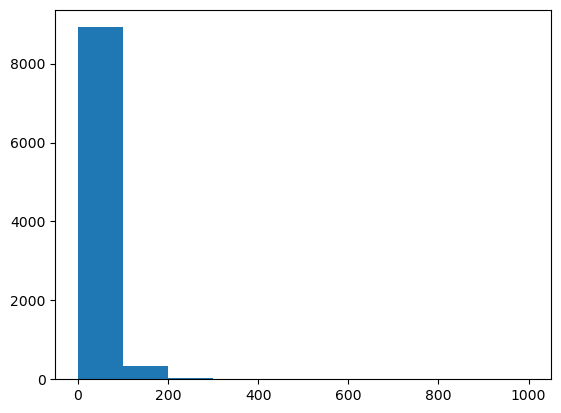

```python
plt.hist(data.pm2_5,range=(0,1000)) #pm2_5
plt.show()
```

# FILL MISSING VALUES BY MEAN (GROUP BY STATE)

```python
grp_state = data.groupby('state')
```

```python
def mean(series):
    return series.fillna(series.mean())
```

```python
data['rspm']=grp_state['rspm'].transform(mean)  #fill value with mean value group by state
data['so2']=grp_state['so2'].transform(mean)
data['no2']=grp_state['no2'].transform(mean)
data['spm']=grp_state['spm'].transform(mean)
data['pm2_5']=grp_state['pm2_5'].transform(mean)
```

```python
data.describe()
```

|  | so2 | no2 | rspm | spm | pm2_5 |
| --- | --- | --- | --- | --- | --- |
| count | 435739.000000 | 435739.000000 | 435739.000000 | 431671.000000 | 123689.000000 |
| mean | 10.589141 | 25.663170 | 109.680907 | 215.198748 | 48.317274 |
| std | 10.863679 | 18.271145 | 72.519399 | 117.470157 | 21.455206 |
| min | 0.000000 | 0.000000 | 0.000000 | 0.000000 | 3.000000 |
| 25% | 4.800000 | 14.000000 | 59.000000 | 142.000000 | 30.729696 |
| 50% | 8.000000 | 21.800000 | 93.000000 | 205.255823 | 42.204089 |
| 75% | 13.000000 | 32.000000 | 142.016832 | 248.000000 | 64.890625 |
| max | 909.000000 | 876.000000 | 6307.033333 | 3380.000000 | 504.000000 |

```python
data.isna().sum() #some null value remains since some state have one value(i.e NaN only) and no mean to replace them
```

```
state            0
location         3
type          5393
so2              3
no2              3
rspm             3
spm           4071
pm2_5       312053
date             7
dtype: int64
```

# Data Distribution after Replacing Null value with mean

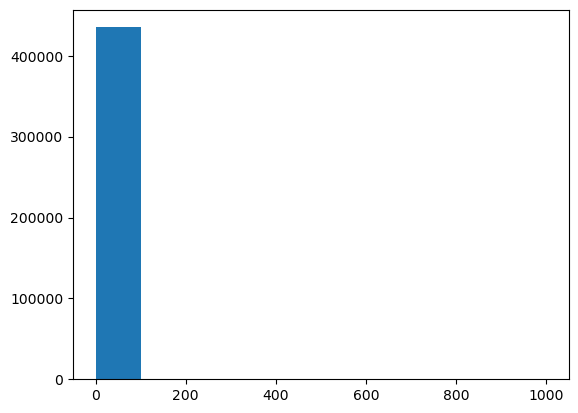

```python
plt.hist(data.so2,range=(0,1000))
plt.show()
```

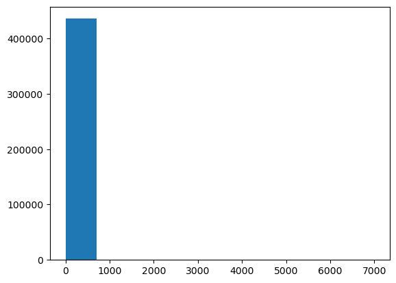

```python
plt.hist(data.rspm,range=(0,7000))
plt.show()
```

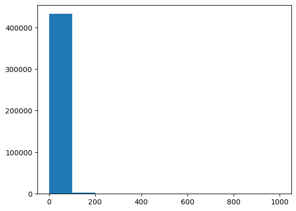

```python
plt.hist(data.no2,range=(0.0,1000))
plt.show()
```

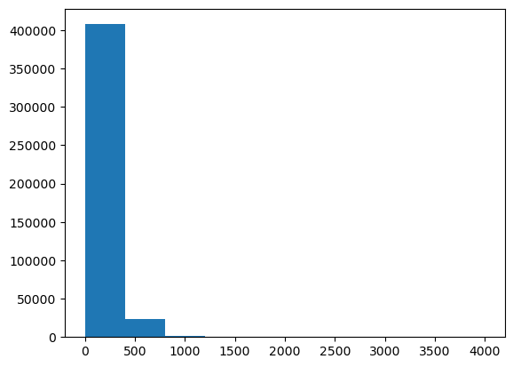

```python
plt.hist(data.spm,range=(0.0,4000)) #spm
plt.show()
```

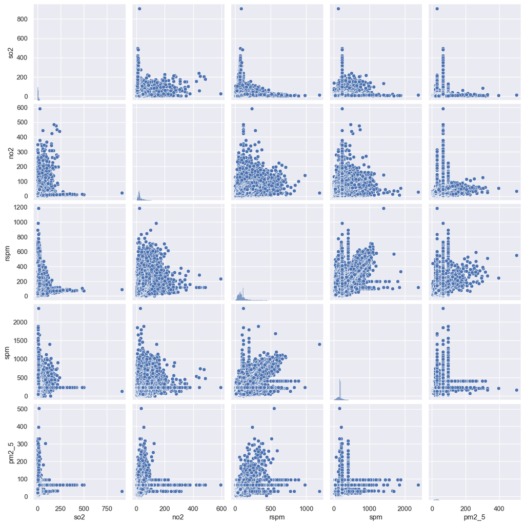

```python
#Scatter plots of all columns
sns.set()
cols = ['so2', 'no2', 'rspm', 'spm', 'pm2_5']
sns.pairplot(data[cols], size = 2.5)
plt.show()
```

[figure not shown]

```python
#Correlation matrix
corrmat = data.corr()
f, ax = plt.subplots(figsize = (15, 10))
sns.heatmap(corrmat, vmax = 1, square = True, annot = True)
plt.show()
```

```python
data.tail(10)
```

|  | state | location | type | so2 | no2 | rspm | spm | pm2_5 | date |
| --- | --- | --- | --- | --- | --- | --- | --- | --- | --- |
| 435732 | West Bengal | ULUBERIA | RIRUO | 22.0 | 50.0 | 145.0 | 233.506524 | 64.890625 | 12/9/2015 |
| 435733 | West Bengal | ULUBERIA | RIRUO | 34.0 | 61.0 | 161.0 | 233.506524 | 64.890625 | 12/12/2015 |
| 435734 | West Bengal | ULUBERIA | RIRUO | 20.0 | 44.0 | 148.0 | 233.506524 | 64.890625 | 12/15/2015 |
| 435735 | West Bengal | ULUBERIA | RIRUO | 17.0 | 44.0 | 131.0 | 233.506524 | 64.890625 | 12/18/2015 |
| 435736 | West Bengal | ULUBERIA | RIRUO | 18.0 | 45.0 | 140.0 | 233.506524 | 64.890625 | 12/21/2015 |
| 435737 | West Bengal | ULUBERIA | RIRUO | 22.0 | 50.0 | 143.0 | 233.506524 | 64.890625 | 12/24/2015 |
| 435738 | West Bengal | ULUBERIA | RIRUO | 20.0 | 46.0 | 171.0 | 233.506524 | 64.890625 | 12/29/2015 |
| 435739 | andaman-and-nicobar-islands | NaN | NaN | NaN | NaN | NaN | NaN | NaN | NaN |
| 435740 | Lakshadweep | NaN | NaN | NaN | NaN | NaN | NaN | NaN | NaN |
| 435741 | Tripura | NaN | NaN | NaN | NaN | NaN | NaN | NaN | NaN |

# CALCULATE AIR QUALITY INDEX FOR SO2 BASED ON FORMULA

The air quality index is a piecewise linear function of the pollutant concentration. At the boundary between AQI categories, there is a discontinuous jump of one AQI unit. To convert from concentration to AQI this equation is used \begin{equation*} I = I_{low} + \frac{I_{high}-I_{low}}{C_{high}-C_{low}}{(C-C_{low})} \end{equation*}

[figure not shown]

**What is sulfur dioxide?**

Sulfur dioxide is a gas. It is invisible and has a nasty, sharp smell. It reacts easily with other substances to form harmful compounds, such as sulfuric acid, sulfurous acid and sulfate particles.

About 99% of the sulfur dioxide in air comes from human sources. The main source of sulfur dioxide in the air is industrial activity that processes materials that contain sulfur, eg the generation of electricity from coal, oil or gas that contains sulfur. Some mineral ores also contain sulfur, and sulfur dioxide is released when they are processed. In addition, industrial activities that burn fossil fuels containing sulfur can be important sources of sulfur dioxide.

Sulfur dioxide is also present in motor vehicle emissions, as the result of fuel combustion. In the past, motor vehicle exhaust was an important, but not the main, source of sulfur dioxide in air. However, this is no longer the case.

```python
def cal_SOi(so2):
    si=0
    if (so2<=40):
     si= so2*(50/40)
    elif (so2>40 and so2<=80):
     si= 50+(so2-40)*(50/40)
    elif (so2>80 and so2<=380):
     si= 100+(so2-80)*(100/300)
    elif (so2>380 and so2<=800):
     si= 200+(so2-380)*(100/420)
    elif (so2>800 and so2<=1600):
     si= 300+(so2-800)*(100/800)
    elif (so2>1600):
     si= 400+(so2-1600)*(100/800)
    return si
data['SOi']=data['so2'].apply(cal_SOi)
df= data[['so2','SOi']]
df.head()
```

|  | so2 | SOi |
| --- | --- | --- |
| 0 | 4.8 | 6.000 |
| 1 | 3.1 | 3.875 |
| 2 | 6.2 | 7.750 |
| 3 | 6.3 | 7.875 |
| 4 | 4.7 | 5.875 |

# CALCULATE AIR QUALITY INDEX FOR NO2 BASED ON FORMULA

```python
def cal_Noi(no2):
    ni=0
    if(no2<=40):
     ni= no2*50/40
    elif(no2>40 and no2<=80):
     ni= 50+(no2-40)*(50/40)
    elif(no2>80 and no2<=180):
     ni= 100+(no2-80)*(100/100)
    elif(no2>180 and no2<=280):
     ni= 200+(no2-180)*(100/100)
    elif(no2>280 and no2<=400):
     ni= 300+(no2-280)*(100/120)
    else:
     ni= 400+(no2-400)*(100/120)
    return ni
data['Noi']=data['no2'].apply(cal_Noi)
df= data[['no2','Noi']]
df.head()
```

|  | no2 | Noi |
| --- | --- | --- |
| 0 | 17.4 | 21.750 |
| 1 | 7.0 | 8.750 |
| 2 | 28.5 | 35.625 |
| 3 | 14.7 | 18.375 |
| 4 | 7.5 | 9.375 |

# CALCULATE AIR QUALITY INDEX FOR RSPM BASED ON FORMULA

```python
def cal_RSPMi(rspm):
    rpi=0
    if(rspm<=100):
     rpi = rspm
    elif(rspm>=101 and rspm<=150):
     rpi= 101+(rspm-101)*((200-101)/(150-101))
    elif(rspm>=151 and rspm<=350):
     ni= 201+(rspm-151)*((300-201)/(350-151))
    elif(rspm>=351 and rspm<=420):
     ni= 301+(rspm-351)*((400-301)/(420-351))
    elif(rspm>420):
     ni= 401+(rspm-420)*((500-401)/(420-351))
    return rpi
data['RSPMi']=data['rspm'].apply(cal_RSPMi)
df= data[['rspm','RSPMi']]
df.head()
```

|  | rspm | RSPMi |
| --- | --- | --- |
| 0 | 78.182824 | 78.182824 |
| 1 | 78.182824 | 78.182824 |
| 2 | 78.182824 | 78.182824 |
| 3 | 78.182824 | 78.182824 |
| 4 | 78.182824 | 78.182824 |

```python
df.tail()
```

|  | rspm | RSPMi |
| --- | --- | --- |
| 435737 | 143.0 | 185.857143 |
| 435738 | 171.0 | 0.000000 |
| 435739 | NaN | 0.000000 |
| 435740 | NaN | 0.000000 |
| 435741 | NaN | 0.000000 |

# CALCULATE AIR QUALITY INDEX FOR SPM BASED ON FORMULA

```python
def cal_SPMi(spm):
    spi=0
    if(spm<=50):
     spi=spm*50/50
    elif(spm>50 and spm<=100):
     spi=50+(spm-50)*(50/50)
    elif(spm>100 and spm<=250):
     spi= 100+(spm-100)*(100/150)
    elif(spm>250 and spm<=350):
     spi=200+(spm-250)*(100/100)
    elif(spm>350 and spm<=430):
     spi=300+(spm-350)*(100/80)
    else:
     spi=400+(spm-430)*(100/430)
    return spi

data['SPMi']=data['spm'].apply(cal_SPMi)
df= data[['spm','SPMi']]
df.head()
```

|  | spm | SPMi |
| --- | --- | --- |
| 0 | 200.260378 | 166.840252 |
| 1 | 200.260378 | 166.840252 |
| 2 | 200.260378 | 166.840252 |
| 3 | 200.260378 | 166.840252 |
| 4 | 200.260378 | 166.840252 |